# Effects of Loan Characteristics on Annual Percentage Rate (APR)

## Dataset Overview

The Loan Data from Prosper data set contains 113,937 loans with 81 variables on each loan, including loan amount, borrower rate (or interest rate), current loan status, borrower income, and many others. See this [data dictionary](https://www.google.com/url?q=https://docs.google.com/spreadsheet/ccc?key%3D0AllIqIyvWZdadDd5NTlqZ1pBMHlsUjdrOTZHaVBuSlE%26usp%3Dsharing&sa=D&ust=1554486256024000) to understand the dataset's variables.

## Distribution of loans over the years

- January has the highest number of loans as expected from starting of new year.
- April has the least number of loans
- 2013 sees the highest number of loans

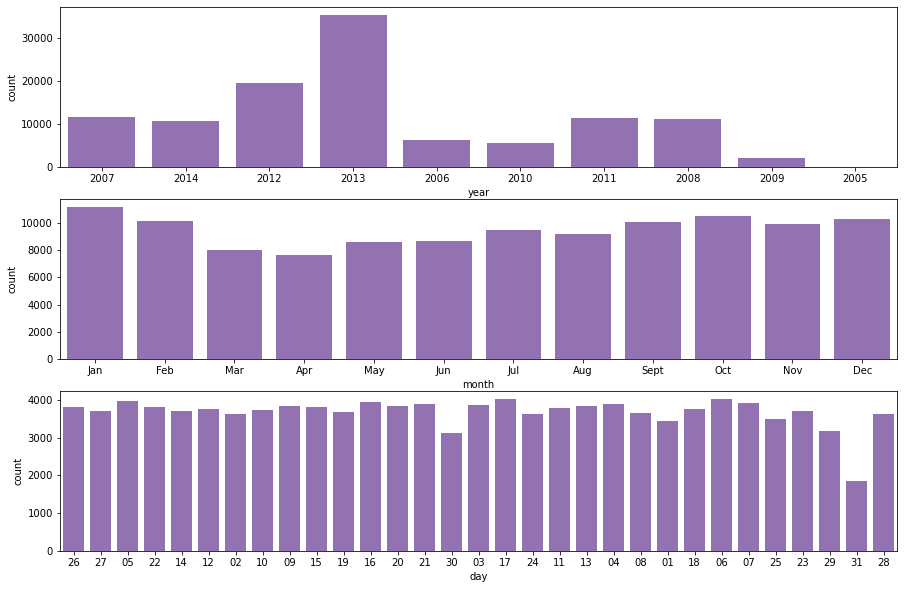

## Distribution of Borrower APR.

We can see an oddly excited record between 0.3 and 0.4. The distribution of APR looks multimodal.

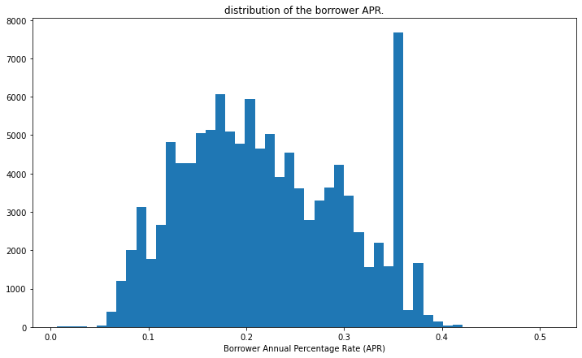

## Distribution of DebtToIncomeRatio

Distribution has unimodal peak around 0.2, which indicates most people prefer 1:4 ratio of debt to Income which is a good thing.

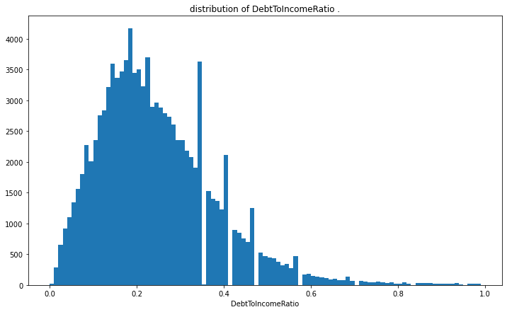

## Distribution of stated monthly income

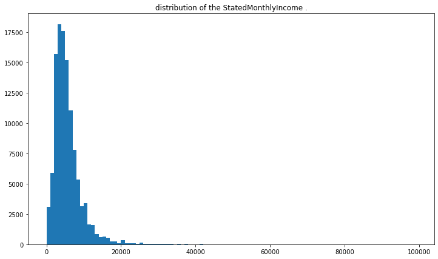

## Borrower APR vs. Loan Amount

Here we see that the borrower APR is negatively correlated with loan amount.

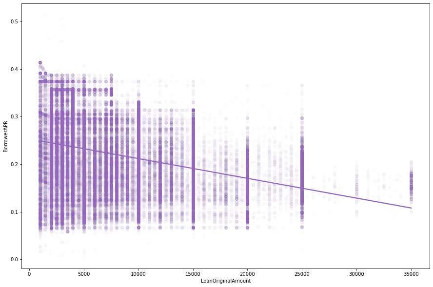

## Borrower APR vs. Prosper Rating

- The borrower APR decreases with the better rating.
- Borrowers with the best Prosper ratings have the lowest APR.

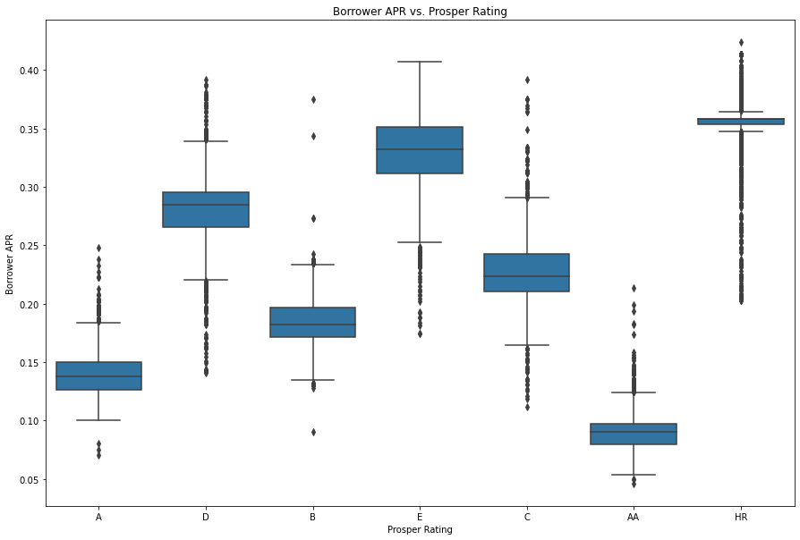

## Term effect on relationship of APR and loan amount

Term doesn't seem to have any effect on the relationship between APR and loan amount

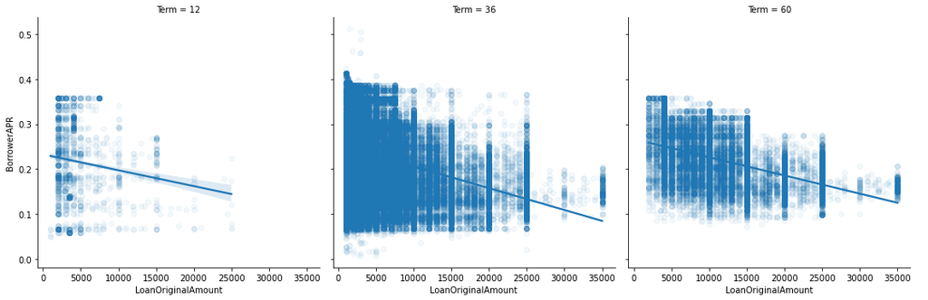

## Prosper rating effect on relationship of APR and loan amount

- The loan amount increases with better rating.
- The borrower APR decreases with better rating.
- The relationship between borrower APR and loan amount turns positive when the Prosper ratings are increased from HR to AA

It's logical that people with better rating (A or AA) tend to borrow more money. People with lower ratings tend to borrow less money, decreasing APR could encourage them to borrow more.

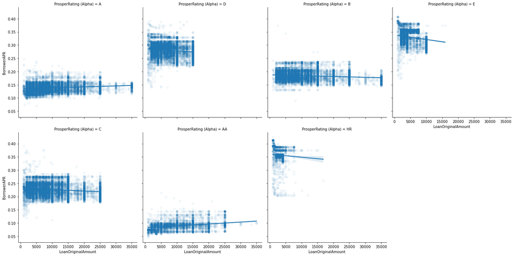

## Borrower APR across rating and term

- We see that the Borrower APR decrease with the an increased Term for people with HR to C raings.
- The APR increase with an increased borrow Term for people with B to AA ratings, .
- Unemployed borrowers have the highest APR

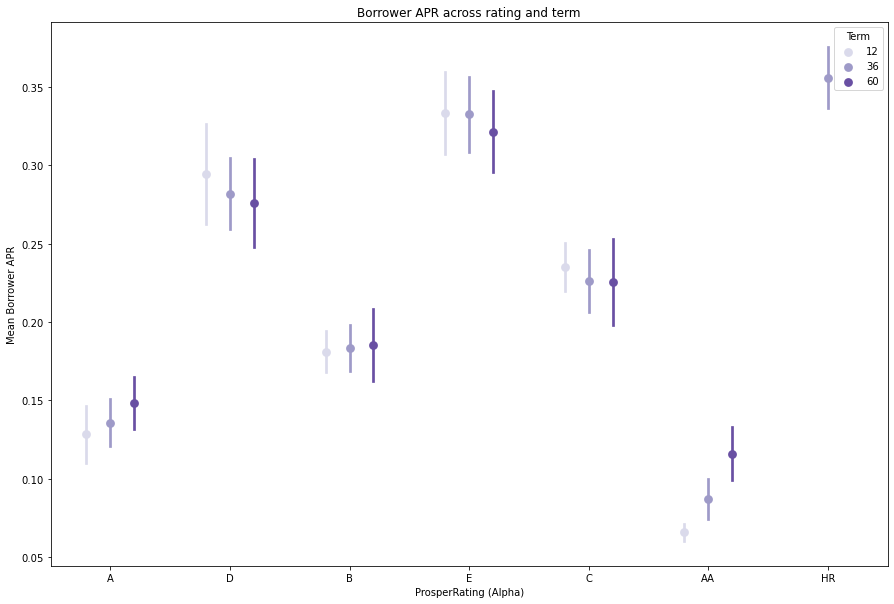

## Borrower APR across Employment Status and Term

- Unemployed borrowers have the highest APR

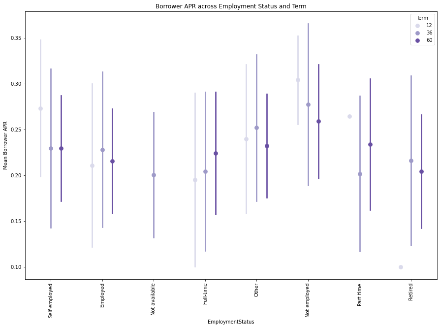

## StatedMonthlyIncome and LoanOriginalAmount by Rating and Term

- For stated monthly income, it doesn't seem like there is an interaction effect between term and rating, the pattern of term is similar among different ratings.
- But for loan amount, there is an interaction between term and rating. With better Prosper rating, the loan amount of each three terms increases.

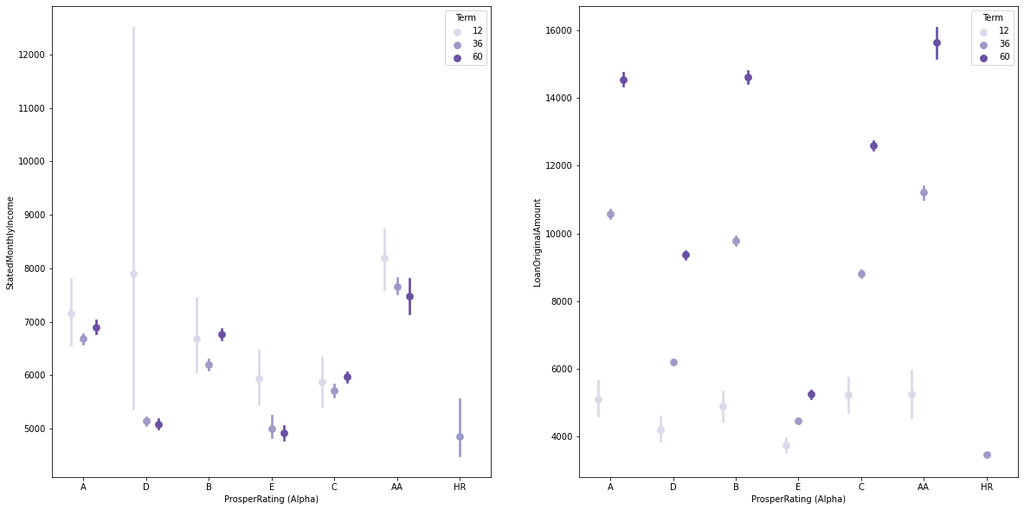